# HHS OCR Healthcare Data Breach Visualization

Analysis of HIPAA breach reports from the [HHS OCR Breach Portal](https://ocrportal.hhs.gov/ocr/breach/breach_report.jsf). Covers breaches affecting 500+ individuals (HITECH Act Section 13402(e)(4)).

**Note on terminology:** The HHS portal reports "Individuals Affected" per breach event. Because the same person's records can be compromised in multiple breaches, the cumulative total (~937M) exceeds the US population. We use **"records exposed"** for aggregated totals.

**Dataset:** 7,382 breach reports | **Period:** Oct 2009 – Jan 2026 | **Total records exposed:** 936,732,042

## 1. Breaches Over Time

Breach reports have grown from ~200/year in 2010–2012 to over 700/year since 2023. Records exposed can spike due to single mega-breaches (e.g., Anthem 2015, Change Healthcare 2024).

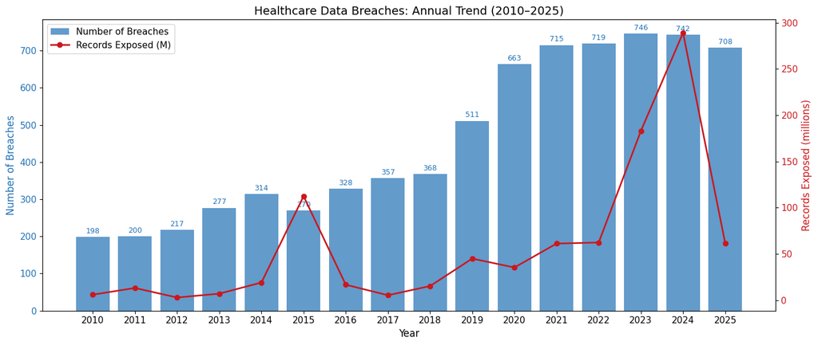

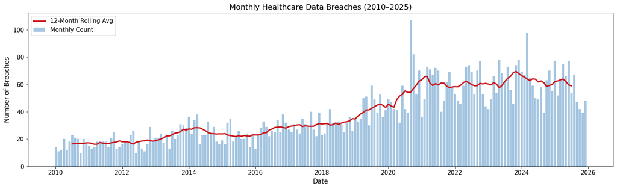

## 2. Type of Breach

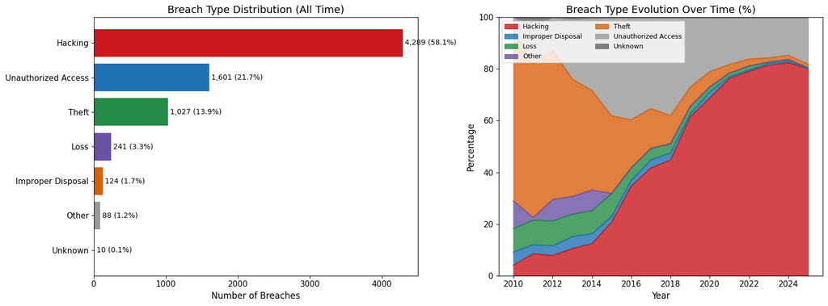

## 3. Location of Breached Information

**Network Server** breaches have surged since 2015 (~41% of incidents), consistent with cloud-hosted EHR adoption. **Email** (phishing) is the second vector. Physical locations (Paper, Laptop) have declined.

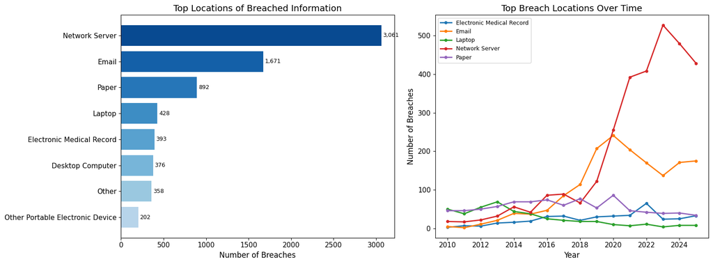

## 4. Geographic Analysis (State Map)

Breach counts follow population: **CA, TX, NY, FL** lead. Records exposed can diverge — states with major insurer HQs dominate due to mega-breaches. Hover for details.

[interactive chart not shown]

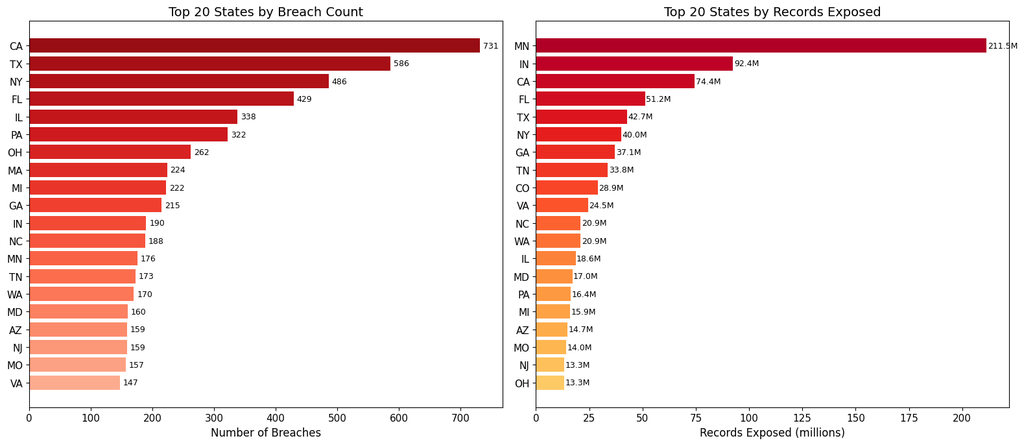

## 5. Entity Type & Business Associate

**Healthcare Providers** account for ~72% of breaches. **Business Associate** involvement (~30%) has been trending upward — reflecting outsourced health IT and supply-chain risks.

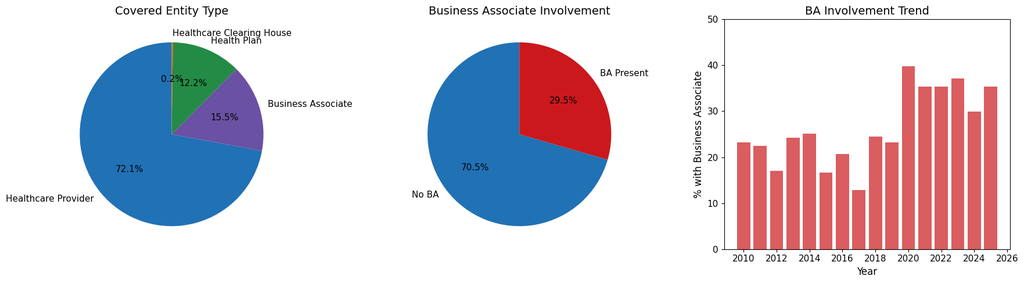

## 6. Scale of Breaches (Records Exposed)

Heavily right-skewed: **median ~4,000 records**, mean ~127,000. The top 20 breaches account for a disproportionate share of total exposure.

[figure not shown]

## 7. Breach Type vs. Location Heatmap

Hacking/IT overwhelmingly targets **Network Servers**. Unauthorized Access is more evenly spread across Email, EHR, and Paper/Films.

[interactive chart not shown]

## 8. State-Level Breach Timeline

Animated map showing geographic spread of breaches year by year. Use the play button below.

[interactive chart not shown]

## 9. Summary Table

Annual statistics at a glance.

| Year | Breaches | Records Exposed | Median/Breach | Max/Breach | % Hacking/IT | % BA Present |
| --- | --- | --- | --- | --- | --- | --- |
| 2010 | 198 | 5,931,716 | 2,037 | 1,220,000 | 4 | 23 |
| 2011 | 200 | 13,162,158 | 2,270 | 4,900,000 | 8 | 22 |
| 2012 | 217 | 2,853,985 | 2,365 | 780,000 | 8 | 17 |
| 2013 | 277 | 7,018,839 | 2,352 | 4,029,530 | 10 | 24 |
| 2014 | 314 | 19,073,551 | 2,674 | 6,121,158 | 12 | 25 |
| 2015 | 270 | 112,466,720 | 2,030 | 78,800,000 | 21 | 17 |
| 2016 | 328 | 16,711,004 | 2,380 | 3,620,000 | 35 | 21 |
| 2017 | 357 | 5,313,246 | 2,081 | 697,800 | 42 | 13 |
| 2018 | 368 | 15,253,935 | 2,412 | 2,652,537 | 45 | 24 |
| 2019 | 511 | 44,969,724 | 4,000 | 11,500,000 | 61 | 23 |
| 2020 | 663 | 35,321,223 | 4,538 | 3,320,726 | 69 | 40 |
| 2021 | 715 | 61,206,238 | 5,269 | 4,142,440 | 76 | 35 |
| 2022 | 719 | 62,351,195 | 7,632 | 4,226,508 | 79 | 35 |
| 2023 | 746 | 183,029,861 | 7,543 | 14,782,887 | 82 | 37 |
| 2024 | 742 | 289,162,330 | 6,702 | 192,700,000 | 82 | 30 |
| 2025 | 708 | 61,560,019 | 4,038 | 13,924,906 | 80 | 35 |

Source: [HHS OCR Breach Portal](https://ocrportal.hhs.gov/ocr/breach/breach_report.jsf) | Generated: 2026-02-10